# Biomolecules: the building blocks of engrams

By: Andrew McKenzie; Last Major Update: 2022-01-31; Status: Draft

- Link to the index: https://brainpreservation.github.io/

## Summary

In this essay we sketch out a bottom-up approach to investigate the building blocks of engrams. We quickly move beyond coherent quantum states and atom variations to get to the level of the biomolecule. Biomolecules can be thought of as having three main features: composition, location, and conformation. To sufficiently describe engrams, the information content of biomolecular composition and location are most likely necessary to preserve at some level of precision. On the other hand, it seems likely that bimolecular conformation can be inferred. The most important aspect of whether biomolecules are important for rapid long-term memory recall is likely whether they function in rapid electrochemical signaling across brain regions. While a bottom-up approach to engram information alone does not answer much about how engrams are stored in the brain, it is a helpful step to narrow down the possible ways that engrams could be stored in the brain before the subsequent essays.

## Quantum states and atoms

All of biology is ultimately dependent on quantum physics. One important aspect of quantum physics is quantum superposition, [which is](https://physics.stackexchange.com/questions/391407/what-is-quantum-coherence-and-decoherence-in-laymans-terms) the non-classical behavior of tiny objects that can allow different values to co-exist simultaneously. Quantum coherence is when this superposition is maintained in larger systems, which can lead to [macroscopic quantum behavior](https://en.wikipedia.org/wiki/Macroscopic_quantum_phenomena).

Theoretically, one might imagine that coherent quantum states could play a role in engram storage. From the perspective of the longevity criterion, a major problem with such a quantum engram storage hypothesis is that the rate of the loss of quantum coherence is extremely fast. Even for the fastest known biological processes, such as photosynthetic light harvesting, it has been shown that coherence of excitons cannot last long enough to play a role in the function of the system [(Cao et al., 2020)](https://advances.sciencemag.org/content/6/14/eaaz4888.full). The fastest cognitive processes have characteristic timescales on the order of microseconds to milliseconds, so quantum coherence has also been suggested to be too unstable to play an important role in rapid cognitive processes [(Tegmark, 2000)](https://arxiv.org/abs/quant-ph/9907009), let alone the long-term storage of engrams that can persist for years. So by the spatiotemporal criterion alone, coherent quantum states are not a plausible mechanism of long-term memory storage.

Above the level of quantum physics, atoms are the fundamental building block of any type of material. (Technically, you need quantum mechanics to explain how atoms work, although as discussed above, quantum coherence is not relevant to neural function.) Some atoms in the brain are long-lived and can last for a lifetime, such as the carbon atoms in DNA molecules, as demonstrated by the long-lived effects of nuclear bomb tests on the isotopes of carbon atoms of people living nearby [(Yeung et al., 2014)](https://pubmed.ncbi.nlm.nih.gov/25417154/). However, variation between atomic isotopes likely cannot be a unique store of information because we know from [fundamental physics](https://physics.stackexchange.com/questions/163826/why-are-atoms-of-the-same-element-exactly-the-same) that atoms of the same isotope are exchangeable without a change in function.

Atoms of different isotopes *can* have different functions in biological systems, especially for light elements such as hydrogen, as a result of differences in their rate of chemical reactions [(Miyagi et al., 2016)](https://www.ncbi.nlm.nih.gov/pmc/articles/PMC5031643/). Stable isotope differences can also be driven by variation in dietary intake [(Correia et al., 2019)](https://analyticalsciencejournals.onlinelibrary.wiley.com/doi/full/10.1002/rcm.8524). However, [differences in the chemical functions of atoms based on their number of neutrons](https://en.wikipedia.org/wiki/Isotope#Isotope_vs._nuclide) are not currently thought to be a major contributor to variation in cognitive function between organisms in natural environments. So this will not be considered in depth. If neuroscience research eventually tells us that some stable isotope differences make important contributions to cognitive functions, then these stable isotope differences would theoretically be able to be preserved and measured as another aspect of biomolecular composition.

## Molecules

Chemical substances in the brain can be distinguished into (a) monatomic substances, which are mainly monatomic ions such as H+, Li+, Na+, or K+, and (b) molecules, which are made of more than one atom. As a result of the longevity criterion, monatomic substances are likely only relevant for long-term storage of engrams insofar as they are stably present in the brain for a long period of time. In that case, for the purposes of this section, they could be considered part of the composition of the molecule to which they are stably anchored.

In terms of molecules, we can distinguish between biomolecules, which are the endogenous molecules found in the body during one’s life, and xenobiotics, which are foreign molecules in that are not expected to be found in the brain, but are present as a result of the dying, preservation, and/or storage processes. Biomolecules are a key level of analysis and the one that we will consider next. If a molecule is technically a xenobiotic because it is produced by a foreign agent, but affects one’s brain function during life, then it will be considered a biomolecule for the purpose of this essay.

## Anchored vs non-anchored biomolecules

Within the brain, there exist interconnected intracellular and extracellular networks of biomolecules, which are largely stabilized by the cytoskeleton and the extracellular matrix. From a biophysics perspective, these biomolecular networks can be thought of as weak gel-like structures. The networks can be stable for years, even if some or all of the individual biomolecules that comprise them are replaced.

For biomolecules, a key distinction is whether the biomolecule is solidly anchored – firmly secured in position – in the brain’s biomolecular networks or not. I use the term anchored in the sense of secured firmly in position. Water molecules are usually an example of a type of non-anchored biomolecule, although there may be exceptions for water molecules that are strongly bound to another molecule, such as in a hydration shell. Other types of non-anchored biomolecules are ones that are exclusively solubilized in water and highly mobile.

In addition to direct binding to weak gel-like biomolecular networks, another type of anchoring can be when a biomolecule’s diffusion is constrained over a long period of time in a local microenvironment, for example in a compartment by an organelle membrane like in a lysosome.

The distinction between anchored and non-anchored biomolecules will often map to the more common distinction in molecular biology between macromolecules and small molecules [(Lodish et al., 2000)](https://www.ncbi.nlm.nih.gov/books/NBK21473/). Small molecules include water as well as small organic molecules such as sugars, hormones, and neurotransmitters. Macromolecules are larger biomolecules. The four major classes of macromolecules are nucleic acids, proteins, lipids, and carbohydrates. Anchored biomolecules tend to be macromolecules and non-anchored molecules tend to be small molecules. However, this distinction is far from absolute, so it is more accurate to speak of anchored as compared to non-anchored biomolecules when we discuss the building blocks of engrams.

A wealth of evidence suggests that it is anchored biomolecules as opposed to non-anchored biomolecules that are responsible for encoding engrams. One clue is that, from a longevity criterion perspective, the longest-lived biomolecules tend to be ones that are anchored as structural components. For example, proteins associated with stable cellular structures, such as nuclear histones, the nuclear pore complex, myelin, and the extracellular matrix tend to have turnover rates on the order of months to years (Toyama et al., 2013). But stronger evidence comes in the form of perturbations that strongly disrupt non-anchored biomolecules without disrupting engram storage; I’m going to list a few examples of these here.

The first example of these perturbations is global cerebral ischemia. During global cerebral ischemia, there are rapid changes in ion distributions in the brain [(Raichle, 1983)](https://onlinelibrary.wiley.com/doi/abs/10.1002/ana.410130103) [(Lee et al., 2000)](https://www.ncbi.nlm.nih.gov/pmc/articles/PMC381398). The initial shutdown of electrical activity is due to the movement of potassium out of neurons, causing neurons to become hyper-polarized and therefore in a state where they effectively cannot fire. A few minutes later, there is another re-organization of ions that causes neurons to become depolarized, which is called anoxic depolarization. This leads to an enormous release of neurotransmitters from synapses. Because so many excitatory neurotransmitters are released, it leads to more cellular depolarization and neurotransmitter release, leading to still further depletion of neurotransmitters and energy stores. Several minutes after the loss of organized electrical activity, microelectrodes placed in the extracellular fluid of the brain show that ion concentrations, such as those of potassium, sodium, hydrogen, and calcium, are dramatically altered relative to baseline conditions [(Heuser et al., 1985)](https://www.sciencedirect.com/science/article/pii/S0007091217432971). So are the concentrations of neurotransmitters such as glutamate [(Lee et al., 2000)](https://www.ncbi.nlm.nih.gov/pmc/articles/PMC381398). And yet, we know that humans and animals can tolerate the total lack of blood flow to the brain at room temperature for certain periods of time, up to 10 minutes, and still be revived without gross neurologic deficits [(Hossmann, 1988)](https://pubmed.ncbi.nlm.nih.gov/3139367/) [(Pennel et al., 2021)](https://pubmed.ncbi.nlm.nih.gov/32815778/). Since long-term memory recall is usually not explicitly mentioned in these clinical studies, we will make the assumption that the absence of neurologic deficits described includes the absence of major long-term memory recall deficits.

The second type of perturbation that disrupts non-anchored biomolecules is cortical spreading depression [(Kramer et al., 2017)](https://pubmed.ncbi.nlm.nih.gov/28088802/). Cortical spreading depression can be induced directly in laboratory animal studies via application of electrodes. It is also thought to occur clinically in traumatic brain injury, certain types of seizures, and transient global amnesia [(Kramer et al., 2017)](https://pubmed.ncbi.nlm.nih.gov/28088802/) [(Ding et al., 2020)](https://www.ncbi.nlm.nih.gov/pmc/articles/PMC7753037/). Cortical spreading depression can lead to a large-scale redistribution of small molecules such as ions and neurotransmitters in the brain as a result of neuronal activity, disruption of the blood brain barrier, osmotic cell and tissue swelling, and other mechanisms. And yet, evidence suggests that cortical spreading depression does not cause the destruction of stored engrams [(Burešová et al., 1969)](https://onlinelibrary.wiley.com/doi/abs/10.1002/neu.480010202). Clinically, people can eventually recover from the conditions associated with cortical spreading depression with the ability to recall long-term memories predominantly intact.

The third type of perturbation that disrupts non-anchored biomolecules is the surgical procedure of total body washout. In this procedure, patients with severe hepatic encephalopathy have their blood almost entirely removed via perfusion with a cold electrolyte solution that also induces protective hypothermia. The electrolyte perfusion is continued until the percent of red blood cells is 1% (normal is around 35-48%), at which point the venous return is only slightly pink-tinged. The purpose of this procedure is to remove toxic small molecules such as bilirubin and ammonia, as well as decrease the levels of abnormally elevated hormones such as antidiuretic hormone and aldosterone [(Klebanoff et al., 1972)](https://pubmed.ncbi.nlm.nih.gov/5078628/). After the total body washout procedure and a period of recovery, people have been reported to not have any resulting neurologic deficits [(Cooper et al., 1977)](https://pubmed.ncbi.nlm.nih.gov/848687/). In the brain, total body washout would be expected to dramatically decrease the concentration of non-anchored biomolecules, proportional in degree to their permeability to the blood-brain barrier. Therefore, this procedure can be viewed as another perturbation data point to suggest that non-anchored biomolecule distributions in the brain do not need to be continuously maintained to allow for retention of long-term memory recall ability.

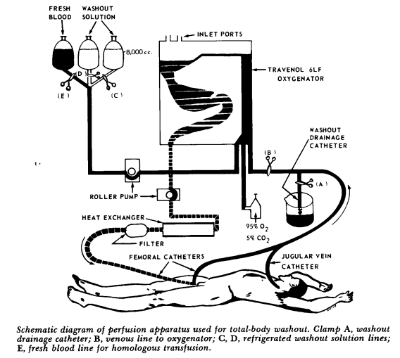

Total body washout; (Cline et al., 1973)

These three perturbations are strong evidence that maintenance of the precise concentration of non-anchored biomolecules, such as ions and neurotransmitters, cannot be necessary for the storage of engrams. However, in all of these types of perturbations, the locations of anchored biomolecules such as the proteins would be expected to be maintained. As a result, once the perturbation has resolved, the non-anchored biomolecule distributions could be re-instantiated as a result of the activity of anchored biomolecules such as enzymes. Notably, recovery of neurologic function from this type of perturbation is not immediate, and re-establishment of non-anchored biomolecule gradients is likely the type of biochemical process that needs to occur prior to recovery of cognitive function.

This relates to the uniqueness constraint. Non-anchored biomolecules are often regulated by other anchored biomolecules, such as synthesis enzymes and transporter molecules [(Jékely, 2020)](https://psyarxiv.com/3tv7p) [(Blakely et al., 2012)](https://pubmed.ncbi.nlm.nih.gov/22199021/). For example, the creation of the small molecule nitric oxide is dependent on the activity of the family of nitric oxide synthase enzymes. If non-anchored biomolecules are lost in the postmortem brain, then the macromolecules that regulate the concentrations of small molecules would become necessary to preserve and measure, because they will be a key inference channel to infer the baseline concentration gradients of small molecules. Whereas if the non-anchored biomolecules were still present, then it may not be necessary to preserve or measure these metabolic macromolecules.

## Biomolecular features

We can consider three features of a biomolecule: its atomic composition, its location, and its conformation. The conformation of a biomolecule refers to its three-dimensional shape. For proteins and nucleic acids, conformation refers to their secondary, tertiary, and non-covalent aspects of quaternary structure, while composition refers to primary structure and covalent aspects of quaternary structure.

### Biomolecular composition

Biomolecular composition refers to the atomic makeup of a biomolecule. Without a doubt, the precise composition of a biomolecule can be an important part of its information content. For example, numerous single amino acid changes have been found to affect protein function in ways that could potentially affect long-term memory recall.

Biomolecular composition sounds straightforward, although it becomes more complicated when multiple biomolecules come together to form a biomolecular complex. If two or more biomolecules are covalently bound together, then that would be considered composition features of the individual biomolecules. Or one could simply think of the complex as one biomolecule. This is ultimately a semantic distinction.

On the other hand, if two or more anchored biomolecules are bound together with a relatively weak non-covalent binding pattern, then they will be frequently binding and unbinding *in vivo*, in a dynamic equilibrium state. In this case, their statistical association in a complex is best thought of as a type of biomolecular location feature. By the longevity criterion, the precise binding state at any given time of such weakly bound biomolecular complexes is unlikely to be necessary for engram information. However, the features of the local environment, such as the pH, ion distribution, or redox potential (henceforth referred to as the “milieu”), that mediate the binding equilibrium, may be necessary for engram information.

Between the two extremes of covalently bound and weakly non-covalently bound biomolecular complexes, we can consider a spectrum of complexes bound non-covalently with different binding strengths. For example, the structure of the DNA double helix is maintained with relatively strong non-covalent bonds [(Privalov et al., 2020)](https://link.springer.com/article/10.1007/s00249-020-01437-w). If the non-covalent interactions in a complex are stable enough, then they would be expected to be preserved by a brain preservation method such as aldehyde-stabilized cryopreservation. Indeed, non-covalent biomolecular complexes are frequently measured by techniques that use glutaraldehyde crosslinking among the first processing steps [(Chen et al., 2016)](https://analyticalsciencejournals.onlinelibrary.wiley.com/doi/full/10.1002/mas.21462). On the other hand, if the non-covalent bonding of a biomolecular complex is so weak that it easily dissociates following perturbations such as minutes of global cerebral ischemia, then it would likely not be preserved by such a method, but it would also likely not be necessary for engram information.

To be more precise about this perturbation discussion, let’s consider a specific example of a non-covalent protein quaternary structure: multimerization. Multimerization is a type of non-covalent protein interaction among subunits of the same protein monomers. Multimerization can clearly affect protein function and it is a common phenomenon, occurring, according to one estimate, in one third of all proteins [(Alaei et al., 2020)](https://www.sciencedirect.com/science/article/abs/pii/S0079610719301683). Multimers tend to be in equilibrium with their component monomer forms. In other words, multimers are constantly assembling and disassembling. This means that based on the longevity criterion, the multimer state of any biomolecular complex at any given time is unlikely to be a long-term store of information relevant to engrams. One of the key factors that contributes to the rate of assembly and disassembly of multimers is the small molecule milieu. We know that small molecules in the brain can be dramatically perturbed by several minutes of total lack of blood flow to the brain, which would be expected to in turn substantially affect multimerization states. And yet engram information survives several minutes of total lack of blood flow to the brain, which is indirect perturbation evidence suggesting that labile multimerization states are likely not essential for long-term memory storage.

### Biomolecular location

The relative location of biomolecules to one another is a crucial type of information content for engrams. For example, an ion channel will have a much different role depending on where in the cell membrane it is located. If all the biomolecules in the brain are still present but completely mixed into a soup it seems obvious that all engram information has been lost.

A particular biomolecular localization pattern that warrants attention is the biomolecular condensate. These are compartments of cells that are separated from other parts of the cell without membranes by phase transitions, such as liquid-liquid phase separation or liquid-gel phase separation. Condensates can form through: (a) biomolecular binding, which would be a composition feature and (b) passive thermodynamic properties [(Lyon et al., 2021)](https://www.nature.com/articles/s41580-020-00303-z). Condensates help to regulate the amount of biochemical activity in different areas of the cell at a given time [(Alberti, 2017)](https://pubmed.ncbi.nlm.nih.gov/29065286/). To the extent that condensates form via passive thermodynamic properties, this would be predictable based on biomolecule location properties and the properties of the small molecule milieu such as pH or osmolarity. As a result, the particular thermodynamic phase state of a condensate at any given time, which can be quite dynamic and reversible [(Uversky, 2019)](https://www.frontiersin.org/articles/10.3389/fphy.2019.00010/full), would not be necessary for engram information on the basis of the uniqueness criterion. From a perturbation criterion perspective, the finding that C. elegans can completely vitrify and devitrify with retention of a long-term olfactory memory [(Vita-More et al., 2015)](https://www.ncbi.nlm.nih.gov/pmc/articles/PMC4620520/) also suggests that liquid condensate phase states are not uniquely necessary stores of engram information, because vitrification would be expected to temporarily alter the liquid phase states.

### Biomolecular conformation

Of the three biomolecular features, conformation is the most vexing. Conformation is likely to be altered early during the dying process due to changes in the concentration of ions and small molecules. Conformation can be altered in cryopreservation as a result of dehydration-induced aggregation and also can be altered in fixation because of intramolecular and intermolecular crosslinking [(Park et al., 2019)](https://www.nature.com/articles/nbt.4281). Biomolecular conformation is also more difficult to measure than biomolecular composition or location.

The first question is whether the conformation state of a biomolecule can affect it in a way that is relevant to long-term memory recall. Here the answer is clearly yes. The shape of a biomolecule affects how it interacts with other biomolecules including processes affecting rapid information flow through the nervous system.

The second question is whether a biomolecule’s composition can be predicted based on its composition. We will focus primarily on proteins because they have the most variable conformations and are involved in almost every functional process in the brain. A classic view for protein conformation – “one sequence, one structure” – is that conformation is inferable from the amino acid sequence-based composition of the protein. For the majority of proteins, this seems to be the case, which explains the “protein folding problem” of predicting the major conformation of a protein from its sequence. If this rule were always true, then it would mean that if a biomolecule’s composition is known, the conformation would not be necessary for engram information due to the uniqueness criterion.

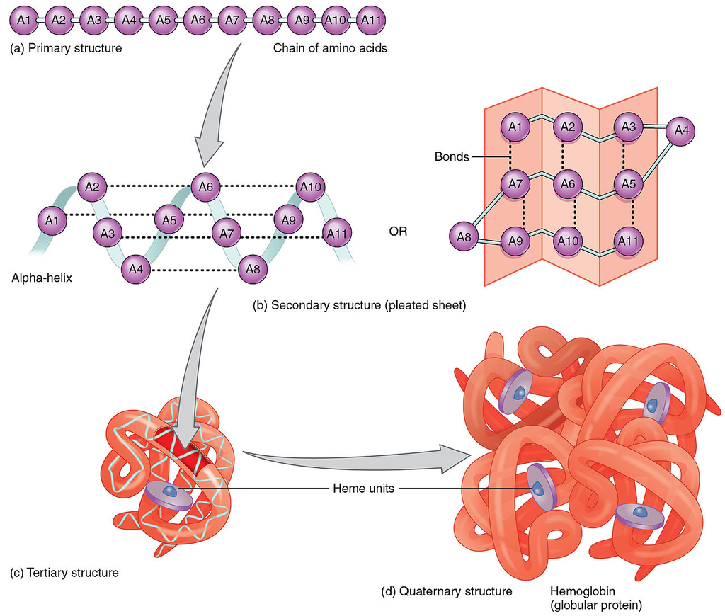

The “protein folding problem” is predicting how its amino acid sequence prescribes its 3d structure; [(n.d.)](https://openstax.org/books/anatomy-and-physiology/pages/2-5-organic-compounds-essential-to-human-functioning)

However, the “one sequence, one structure” rule is not always true. We will examine exceptions to the rule and see whether, in these cases, protein conformation may play a role in engram information storage.

The first exemption to the “one sequence, one structure” rule is post-translational modification. Post-translational modification frequently leads to a change in the conformation of the protein and can clearly have functional effects. For example, when a neurotransmitter receptor is phosphorylated, this can lead to a change in the conformation of a neurotransmitter-gated ion channel and modulate its channel properties (Talwar et al., 2014). As post-translational modifications are covalent bonds that change the composition of the protein, they are an exemption to the “one sequence, one structure” rule, but not to an extended “one composition, one structure” rule, so they are not a reason that biomolecular conformations might be uniquely important for engram information beyond their composition.

A second exemption to the “one sequence, one structure” rule are intrinsically disordered protein regions. These regions of proteins have no stable conformation, which explains the name “intrinsically disordered.” They are quite common; for example, 28% of mouse proteins have been predicted to be mostly disordered [(Oldfield et al., 2005)](https://pubs.acs.org/doi/10.1021/bi047993o). To the extent that intrinsically disordered proteins regions have a conformational continuum at all, it should still be predictable based on the sequence and the milieu. Indeed, intrinsically disordered protein regions can often be predicted based on basic properties of the protein sequence, such as hydropathy and the distribution of charged amino acids [(Uversky, 2019)](https://www.frontiersin.org/articles/10.3389/fphy.2019.00010/full). And to the extent that intrinsically disordered proteins regions do not have a conformation at all, then it is not necessary to preserve or predict it, as it would not be informative. The absence of conformation is why disordered proteins tend to maintain their function even after exposure to prolonged harsh environmental conditions – as Uversky puts it, “one cannot break what’s already broken” [(Uversky, 2019)](https://www.frontiersin.org/articles/10.3389/fphy.2019.00010/full). Therefore, while intrinsically disordered protein regions are an exemption to the “one sequence, one structure” rule, they are not a reason that conformation might be uniquely important for engram information.

A third exemption to the “one sequence, one structure” rule is metamorphic proteins. Metamorphic proteins have more than one stable conformation that is often associated with a different function. They have been estimated to include 0.5-4% of proteins [(Porter et al., 2018)](https://www.pnas.org/content/115/23/5968). Sometimes the different conformations are associated with an alteration in covalent bonding in the protein, such as an intramolecular disulfide bond, which is just another example of how a protein’s composition can affect its conformation. But sometimes metamorphic proteins shift conformation solely based on the milieu, such as the pH, ion distributions, redox potential, local mechanical tension, or concentration of small molecules. The conformation state of metamorphic proteins that switch conformation based on the milieu would not contain unique information for engrams above and beyond that contained in the milieu; although they would require accurate inference of the relevant milieu based on the anchored biomolecules if their conformation was lost and it played a direct role in memory recall.

A theoretical exception to the inferability of a metamorphic protein’s conformation is if it exhibits hysteresis. Hysteresis is a dependence of a state on its history. For example, one might imagine that a metamorphic protein’s conformation could change in response to a difference in the milieu, and that even when the milieu changes, the protein conformation could remain the same. To play a role in engram information storage, this hysteretic protein conformation would have to remain stable for a very long time, on the timescale of years to decades, or somehow transmit this information to other proteins. There are some clues that protein folding may exhibit hysteresis. For example, synonymous codon substitutions that do not affect protein composition seem to have an effect on the folding pattern and resulting conformational state of proteins [(Walsh et al., 2020)](https://www.pnas.org/content/117/7/3528). I am not aware of any metamorphic proteins that have displayed such conformational longevity, although it seems theoretically possible. However, there is another class of proteins that can have stable, long-lasting conformation states, which is amyloids. Amyloids are the fourth exemption to the “one sequence, one structure” rule.

Amyloids are aggregates of proteins arranged in a fibrillar shape containing a cross-beta conformation. The conversion of proteins into amyloids results from a nucleation mechanism such as misfolding. This means that the conformation of amyloids cannot be predicted by the amino acid sequence alone and is instead dependent on the history of the protein [(Malmberg et al., 2020)](https://www.frontiersin.org/articles/10.3389/fnins.2020.00256/full). A prion is a particular type of amyloid that is able to “infect” proteins in other environments by converting them to the abnormal conformations that lead to the fibrillar structure [(Malmberg et al., 2020)](https://www.frontiersin.org/articles/10.3389/fnins.2020.00256/full) [(Requena, 2020)](https://journals.plos.org/plosbiology/article?id=10.1371/journal.pbio.3000754). In addition to disease-associated amyloids, there are also functional amyloids that form amyloid fibrils for a regulated purpose in the cell, such as the storage of peptide hormones [(Jackson et al., 2017)](https://www.mdpi.com/2218-273X/7/4/71).

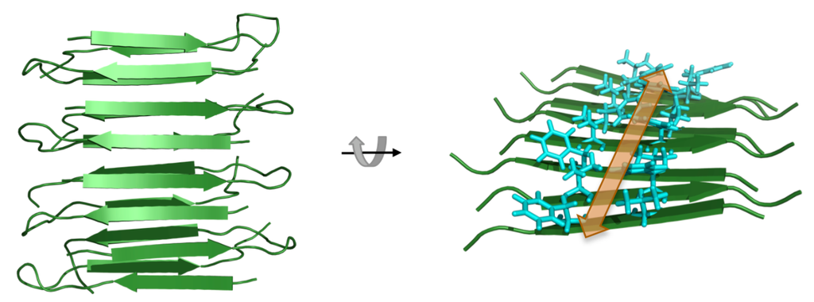

Cartoon of the cross-beta structure of the Iowa-mutant amyloid beta; [(Danoff et al., 2015)](https://journals.plos.org/plosone/article?id=10.1371/journal.pone.0132301)

Some proteins that contain the amyloid-like or prion-like ability to aggregate and propagate have been associated with the storage of memory. This makes sense because these proteins can mediate a long-term phenotype change independent of the genome. Such proteins include cytoplasmic polyadenylation element-binding protein (CPEB), which is found at the synapse [(Si et al., 2016)](https://www.ncbi.nlm.nih.gov/pmc/articles/PMC4817803/). CPEB has two conformational states, one of which is monomeric and one of which is associated with aggregation and long-term persistence [(Si et al., 2016)](https://www.ncbi.nlm.nih.gov/pmc/articles/PMC4817803/). Functional amyloids and prions also form due to a nucleation event and their ability to store long-term states is associated with their aggregation [(Sudhakaran et al., 2016)](https://www.ncbi.nlm.nih.gov/pmc/articles/PMC5449092/).

There is a difference between amyloid-like molecules playing a role in the process of memory storage, which seems plausible, and their conformations playing a *unique* role in engram information storage, which seems very unlikely. The conformation states of amyloids and their functions are associated with aggregation in the form of fibrils, which means that the conformation states would be redundantly coded in the composition or location features of the components of the fibril. The proposed candidates also operate through complex biomolecular networks of other biomolecules, and as a result, indirectly affect long-term memory recall. If one component of this complex biomolecular network were altered, the other components would still retain the information. As a result, while amyloids are an exemption to the “one sequence, one structure” rule, amyloid conformation states seem very unlikely to uniquely store engram information.

A fifth exemption to the “one sequence, one structure” rule is that proteins can change their conformation – unfold – in response to mechanical forces. Long protein chains in particular can have individual domains that demonstrate independent unfolding/refolding behavior when mechanically stimulated [(Mora et al., 2020)](https://pubs.rsc.org/en/content/articlehtml/2020/cs/d0cs00426j). This is an exemption to the “one sequence, one structure” rule – and it might be relevant to biological function, because a partially unfolded protein could function differently from a fully folded protein. The conformation states of one mechanosensitive protein with independent domains, talin, have been proposed to play a role in memory storage in the brain [(Malmberg et al., 2020)](https://www.frontiersin.org/articles/10.3389/fnins.2020.00256/full). However, talin’s conformation states only last a few minutes (as cited in [(Malmberg et al., 2020)](https://www.frontiersin.org/articles/10.3389/fnins.2020.00256/full)). In order to have longevity, the unfolded domains need to be stabilized by binding to other proteins such as vinculin, which is only able to bind to the unfolded conformation state [(Goult, 2021)](https://www.frontiersin.org/articles/10.3389/fnmol.2021.592951/full). Therefore, even if talin’s folded/unfolded conformation states do play a significant role in memory storage, its conformation states alone would not be necessary for engram information due to the uniqueness criterion. In general, if a protein is mechanically unfolded and then the mechanical force is removed, the protein typically refolds back to its original conformation. As [(Mora et al., 2020)](https://pubs.rsc.org/en/content/articlehtml/2020/cs/d0cs00426j) put it, “once a protein is mechanically unfolded, removing the stretching force typically results in the protein refolding back into its folded conformation, recovering the mechanical stability of the protein’s native state.” So while other mechanosensitive proteins surely remain to be discovered and may play a role in memory storage, it seems likely that a similar principle will hold that their conformation states will lack the conformational stability to uniquely mediate engram storage on their own.

The discussion of biomolecular conformation so far has focused on proteins, which have a wider diversity of conformations. But what of non-protein biomolecules?

Lipids are of particular importance in the brain, making up approximately half of its dry weight [(Piomelli et al., 2007)](https://www.nature.com/articles/nrn2233). Given our current state of knowledge, lipids seem to have much less conformational diversity than proteins. The conformational diversity that is present in lipids appears to be predictable by its composition. For example, membrane lipids can have cylindrical, conical, or wedge-like geometries [(Mironov et al., 2020)](https://www.ncbi.nlm.nih.gov/pmc/articles/PMC7590041/), which in turn can have an effect on membrane properties [(Lauwers et al., 2016)](https://pubmed.ncbi.nlm.nih.gov/27054615/). But the molecular geometries of lipids are predictable based on their composition; in particular, the difference in size (if any) between its polar head group and its nonpolar tail [(Piomelli et al., 2007)](https://www.nature.com/articles/nrn2233). So it doesn’t seem that the conformation of lipids has significant unique information above and beyond their composition and location. One important aspect of membrane lipids is that their composition and location can affect the conformation of the embedded proteins, which in turn can clearly affect electrophysiologic properties that seem relevant to long-term memory recall [(Lauwers et al., 2016)](https://pubmed.ncbi.nlm.nih.gov/27054615/).

From a brain preservation perspective, lipids are among the most controversial biomolecules. They are a constant thorn during preservation procedures, and are wont to be extracted by agents that otherwise preserve the contents of biospecimens. It is unclear the degree to which they represent unique, subcellular data that is not already covered by proteins.

For example, [(Carlemalm et al., 1985)](https://onlinelibrary.wiley.com/doi/abs/10.1111/j.1365-2818.1985.tb02660.x) poses a key question about whether lipid preservation matters for cell membrane information, in the context of electron microscopy:

> The loss of membrane lipids might eventually lead to rather drastic consequences. A protein rich membrane, in which the proteins are close enough to each other to be cross linked by the aldehydes, will most probably stay intact enough to give significant biological information. The lipids are replaced by the resin as it replaces the cellular water. A lipid rich membrane can, in the worst case, dissolve with total loss of structural information, since the membrane proteins are too far away from each other to be cross linked.

The relevance of lipids to engram information content remains very much an area of uncertainty. And it is an important area of uncertainty, because several brain preservation methods involve extraction of lipids or otherwise cause damage to lipids. More on lipids in an endnote of this essay.

Like proteins, nucleic acids also have significant conformational diversity, with primary to tertiary structures that can play a role in their functions [(Belmont et al., 2001)](https://pubs.rsc.org/en/content/articlehtml/2001/cs/a904630e). As with proteins, it seems that their conformation is generally predictable based on the nucleic acid sequence. Moreover, most nucleic acid functions are likely too slow to directly participate in rapid long-term memory recall and are therefore not necessary by the spatiotemporal criterion. However, genetic and epigenetic information could be an important source of engram inference if cellular properties are damaged.

Carbohydrates tend to take on particular conformations as well, such as helical secondary structures in polysaccharides, and this affects their interactions with other biomolecules [(Fittolani et al., 2020)](https://onlinelibrary.wiley.com/doi/abs/10.1002/pep2.24124). The binding of carbohydrates to proteins can also affect the conformation of proteins [(Schnaar et al., 2014)](https://www.ncbi.nlm.nih.gov/pmc/articles/PMC4044301/). Based on thermodynamic principles, it seems likely that carbohydrate conformation would be predictable from its composition and milieu. The field of carbohydrate conformation appears to be relatively understudied, which makes it difficult to make definitive statements about it.

#### Biomolecular conformations seem to not uniquely store engram information content

Clearly, the conformation states of biomolecules affect their functions. However, biomolecular conformation states seem to not be *uniquely* necessary for engram information, because conformation states seem able to be inferred from the location and composition information of the biomolecule and, if necessary, its neighboring biomolecules. This matters because brain preservation techniques – both cryopreservation and fixation-based approaches – can lead to alterations in biomolecular conformations.

But we can imagine: what would be required for me to be wrong about this? How might a hypothetical biomolecule conformation state have a unique role in storing engram information?

It would require a biomolecule to have a hysteretic conformation state that is independent of its composition or location and that directly plays a role in long-term memory recall. Morever, this conformation state would need to be lost during the brain preservation procedure.

Because of these multiple requirements, each of which is individually unlikely, I would be very surprised if such a biomolecule conformation state did exist in the brain. I certainly don’t know of any examples or plausible candidates.

However, such a biomolecule conformation state is still theoretically possible. We don’t yet have a complete database of all the biomolecules in the brain with all of their properties to query and check whether such a biomolecule exists. As a result, there remains a slight degree of uncertainty about biomolecular conformation as a hypothetical building block of engrams.

## Abstract structural features composed of biomolecules

All biology is based on biomolecules. Yet, when we consider the coordinated functions of biomolecules, it is often helpful to think of the higher-level structural features that they create, such as organelles, cell membranes, synapses, or something similar. We can consider our higher-order concepts for these groups of associated biomolecules to be abstractions, which we can therefore call an abstract structural feature.

Distinguishing biomolecules from abstract structural features is obviously a false dichotomy that has more to do with our state of knowledge and measurement techniques than the underlying biology. For example, consider the characteristic structure of a synapse, which was not seen until the 1950s, with the development of electron microscopy [(Burette et al., 2015)](https://www.ncbi.nlm.nih.gov/pmc/articles/PMC4517447/). The image of a synapse under electron microscopy, either a 2d image of a section or a 3d volume reconstructed image, has become a canonical way to think about synapses.

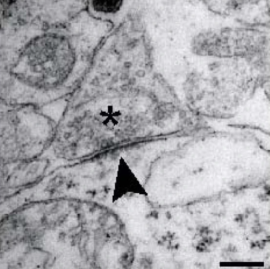

2d electron micrograph of a synapse; presynaptic vesicles = asterisk, postsynaptic density = arrowhead; [(Heupel et al., 2008)](https://neuraldevelopment.biomedcentral.com/articles/10.1186/1749-8104-3-25)

However, it’s important to remember that this is not a synapse, but rather a picture of a synapse. In other words, [the map is not the territory](https://en.wikipedia.org/wiki/Map%E2%80%93territory_relation). Actual synapses involve the coordinated action of thousands of types of biomolecules and are therefore much more detailed. To discuss the function of an abstract structural feature is to assert a degree of model simplification away from the individual biomolecules. As the saying goes: All models are false, but some are useful.

When considering the role of individual types of biomolecules in encoding engrams, we could imagine two extreme possibilities. The first extreme is that no individual type of biomolecule is necessary to preserve and measure. Instead, it might only be necessary to preserve and measure enough biomolecules to retain and capture the information about the abstract structural features that they comprise. For example, one could imagine that it might only be necessary to preserve enough information that can be measured by high-resolution electron microscopy images. The second extreme is to reject the idea that model simplification is possible for valued human cognitive processes and instead state that all of the biomolecules are necessary to preserve and measure.

Most likely, the truth is somewhere in between these two extremes. Much of the information that is necessary for engrams is likely contained within abstract structural features that only require the preservation of an arbitrary subset of their constituent biomolecules. At the same time, there are likely some biomolecules that contain information necessary for engrams beyond their contribution to abstract structural features. To further characterize which biomolecules and abstract structural features are likely to be essential for engrams, we will consider in more detail their functions within the brain.

### The information content of biomolecules and abstract structural features for engrams can be predicted based on their functions

We will distinguish three major functions of biomolecules and abstract structural features in the brain: cell homeostasis, neural plasticity, and rapid electrochemical communication between cells. A biomolecule can be involved in any number of these functions.

1. *Cellular homeostasis* involves maintaining cellular energy stores, replacing damaged biomolecules, performing cell division to maintain stem cell pools, and many other functions that are necessary to keep brain cells functioning. When homeostasis mechanisms malfunction, it can spell trouble in the short or long run for cognition. But homeostasis mechanisms do not directly affect cognition functions.

Much of the homeostatic machinery is not unique to each cell. So biomolecules operating in the capacity of homeostatic machinery are not necessary to preserve or measure from the perspective of engram information. For example, the DNA repair enzymes of a cell are clearly necessary for cell survival and function, but are expected to have minimal unique effect on engram information content unless they have a pleiotropic function in some biological process other than DNA repair.

2. *Neural plasticity* refers to the ability of cells and the nervous system to change. The timescale of neural plasticity can be thought of as occurring relative to a particular cognitive function. Relative to any cognitive function, neural plasticity is defined as operating too slowly to directly affect its moment-to-moment instantiation, but instead acting to change the way the cognitive function operates, in the short term and/or the long term. Because of the spatiotemporal constraint, neural plasticity mechanisms for rapid long-term memory retrieval are not necessary for engrams.

Neural plasticity is often conceptualized as biomolecules involved in changes of synaptic strength, transport machinery that allows the movement of macromolecules around the cell, or nuclear gene expression machinery such as epigenetic states that specify how a neuron will respond to a stimulus. Based on the definition used here, neural plasticity for rapid long term memory recall should also include biomolecules that function in slower neural processes that can indirectly affect the rapid communication across brain regions on the timescale of hundreds of milliseconds.

One example of biomolecules involved in neural plasticity are slow-acting metabotropic receptors. As opposed to ionotropic receptors, which respond to ligands by affecting microsecond to millisecond timescale ion flow through membranes [(Quast et al., 2019)](https://pubmed.ncbi.nlm.nih.gov/31163201), slow-acting metabotropic receptors lead to second-messenger responses that take seconds to hours to affect cellular function [(Lohse et al., 2008)](https://www.ncbi.nlm.nih.gov/pmc/articles/PMC2268076/). So while ionotropic receptors are necessary to preserve or at least be able to infer in order to preserve long-term memory recall, purely slow-acting metabotropic receptors would generally not be, except insofar as they are uniquely important in affecting the local biochemical milieu. An important note here is that there are some fast-acting metabotropic receptors that could potentially function on the timescale of milliseconds and might play a direct role in rapid long-term memory recall.

Another example of a neural plasticity mechanism with respect to long-term memory recall is astrocyte calcium waves. Astrocyte signaling via calcium waves can be involved in promoting neural network synchronicity. However, these calcium waves take seconds to propagate, not milliseconds like the rapid ion-based flow of information through neurons across brain regions [(Santello et al., 2019)](https://pubmed.ncbi.nlm.nih.gov/30664773). Based on these findings, astrocyte calcium waves would be considered a plasticity mechanism from the perspective of rapid long-term memory recall, albeit of an electrochemical type.

That said, for slower cognitive processes such as variability between people in their ability to learn, neural plasticity likely plays a direct role. As [Ken Miller](https://brainslab.wordpress.com/2020/09/11/archiving-the-hayworth-miller-2019-debate-about-brain-preservation/) pointed out in a 2019 Twitter debate with Ken Hayworth, the desire to preserve synapse-by-synapse plasticity and one’s unique propensity to learn new things might mean that a wider set of biomolecules needs to be preserved than are needed to preserve fast ion flow in the brain. This is why we must be precise about what type of cognitive functions we are interested in preserving.

Much of the literature on memory refers to the types of cellular functions that allow organisms to learn. Understanding how this process works will almost certainly be essential in order to read out engrams in a preserved brain or perform revival after brain conservation. However, the biomolecules and abstract structural features necessary for the plasticity of memory are distinct from those necessary for the information content of already formed engrams.

3. The third biomolecular function is the *millisecond-scale electrochemical flow of information between cells across brain regions*. This is the main biomolecular function that is poised to be involved in rapid cognitive functions such as long-term memory recall.

What do we refer to by the electrochemical flow of information between cells? Electrochemical information flow is primarily based on the controlled motion of ions. When we speak of ion-based communication in the nervous system, we are referring specifically to salt ions [(Flood et al., 2019)](https://pubs.acs.org/doi/abs/10.1021/acs.chemrev.8b00630). Long-term, ion-based voltage gradients are established across cell membranes due to biomolecular activity such as ion pumps. This is one of the most energetically costly processes that the brain does. What it allows for is rapid neural information flow when ions flow down the established electrochemical potential gradients [(Levin, 2007)](https://pubmed.ncbi.nlm.nih.gov/17498955/).

Ions move primarily as a result of electrodiffusion, which is diffusion biased by electrical fields. Other than electrodiffusion, other physical factors, such as thermal, mechanical, and magnetic factors can also affect ion flow, but it is thought that these can usually be ignored because they seem to play only a minor role in practice [(Goldman, 1989)](https://link.springer.com/chapter/10.1007/978-1-4614-7516-3_9). When ion channels are activated, they tend to change conformation to allow ions to flow through them. Because ion channel conformation has poor longevity, their particular conformation states at any given time are highly unlikely to be necessary to preserve and measure for engrams. However, our ability to predict the conformation state distributions of ion channels to a sufficient degree of accuracy based on the local milieu is likely to be necessary for engram information [(Flood et al., 2019)](https://pubs.acs.org/doi/abs/10.1021/acs.chemrev.8b00630).

Taken together, any biomolecule that affects the baseline distribution and rapid movement patterns of Na+, K+, Ca2+, Cl-, H+, and other relevant ions could be involved in the information content of rapid ion-based electrochemical flow. This includes ion channels, ion transporters, ion pumps, ionotropic receptors, regulatory proteins that affect their states, and numerous other biomolecules.

## Summary of bottom-up approach to engram information

The building blocks of engrams are likely biomolecules and/or abstract structural features that function in rapid electrochemical ion flow. For biomolecules, the building blocks are likely those that are anchored to stable molecular networks in the brain. In my opinion, it is the location and composition content about biomolecules that matters. However, there remains a degree of uncertainty about the importance of conformation, including the theoretic possibility of long-term hysteresis, and more uncertainty if one imagines a brain preservation method in which lipids are not retained. We now turn our attention to how biomolecules and/or abstract structural features can be used in the description of the connectome and what level of description may be sufficient for engrams.

## Endnotes

### How lipid biomolecules in cell membranes could affect ion flow

Lipid biomolecules in the cell membrane of a cell could affect ion flow through brain cells in many ways.

1. Theoretically, one might imagine that ions could flow through cell membranes independently of ion channels and that this might affect ion flow. However, this seems to not be the case, as phospholipid bilayers on their own are extremely good insulators and as a result no ions flow through them at any given time. From the insulation perspective, lipids in cells can likely be abstracted away or easily inferred.

2. Lipid composition could affect the capacitance properties of the membranes, which are based on membrane thickness and the dielectric constant [(Niebur, 2008)](http://www.scholarpedia.org/article/Electrical_properties_of_cell_membranes). For example, higher levels of cell membrane cholesterol are associated with thicker cell membranes [(Postila et al., 2020)](https://link.springer.com/article/10.1007/s12035-019-01775-7). In addition to ion concentration gradients, the [electrical gradient](https://en.wikipedia.org/wiki/Electrochemical_gradient) across the membrane affects how ions will flow into and out of the cell. However, evidence has suggested that capacitance varies only slightly across cell types and very little with different densities of proteins embedded in the membrane [(Gentet et al., 2000)](https://www.sciencedirect.com/science/article/pii/S000634950076293X). As a result of the finding that capacitance is so similar in so many different mammalian cells, it has been called a “biological constant” [(Gentet et al., 2000)](https://www.sciencedirect.com/science/article/pii/S000634950076293X). Therefore, it is likely that the effects of lipid composition on membrane capacitance would likely be relatively easy to infer even if the underlying lipids were not profiled.

The biomolecular content of myelin can affect its function. Overall, myelin has a high lipid to protein content ratio, at 2:1, in contrast to the brain as a whole, which has more protein content than lipid content [(Fewou et al., 2009)](https://link.springer.com/referenceworkentry/10.1007%2F978-0-387-30378-9_10). This makes it susceptible to losses during lipid extraction, although I am not aware of evidence that heterogeneity in lipid composition between myelin sheaths plays a major role in shaping properties of myelin that are relevant to ion flow down axons. There is one example of a myelin protein that affects the flow of ions down axons, which is the protein claudin-11. Claudin-11 helps to coordinate tight junctions between myelin lamellae that decrease diffusion and therefore increase the electrical resistance of the myelin sheath, which is especially important for small diameter axons [(Denninger et al., 2015)](https://www.ncbi.nlm.nih.gov/pmc/articles/PMC4601091/). However, this appears to be primarily relevant only in the case of organisms that lack claudin-11, which would be appreciable from easily accessed genetic information. Additionally, tight junctions may be visible as ultrastructural features.

3. Lipid composition can affect the conformation of ion channel proteins and therefore how ions flow through the cell. This is a common phenomenon. Lipids can affect conformation by binding to ion channels both as cofactors and as ligands [(Hansen, 2015)](https://www.ncbi.nlm.nih.gov/pmc/articles/PMC4540326/) [(Tian et al., 2019)](https://www.pnas.org/content/116/17/8591.short). Differences in cholesterol levels between synapses has been shown to affect the open probability of NMDA receptor ion channels [(Korinek et al., 2020)](https://www.nature.com/articles/s41598-020-69454-5), which may be through an effect on its conformation.

Endocannabinoids, which are a type of lipid, have also been shown to play a role in regulating the function of ion channels. For example, one study in rats suggests that the endocannabinoid 2-arachidonoylglycerol binds to Kv7.2 ion channels, possibly displacing cholesterol, and thereby changing the intrinsic neuronal excitability of a type of interneuron [(Incontro et al., 2021)](https://www.biorxiv.org/content/10.1101/2021.01.08.426009v1). One question is how long of a time period these lipid binding effects are stable. In this study, the effect was said to be “long lasting” because it lasted for at least 30 minutes [(Incontro et al., 2021)](https://www.biorxiv.org/content/10.1101/2021.01.08.426009v1), which is obviously not close to the timescale over which engrams are known to be maintained.

4. Lipid composition may affect ion flow through the function of lipid rafts. These are microdomains within the cell membrane that contain different compositions of lipids and appear to play a role in rapid electrochemical signaling in the brain, for example at the synapse [(Egawa et al., 2016)](https://www.ncbi.nlm.nih.gov/pmc/articles/PMC4983616). Lipid rafts can be shaped by proteins, such as caveolin proteins, so their presence may be largely inferable by the presence of these proteins.

5. Lipid composition can affect ion flow by affecting biophysical properties of the cell or organelle membrane such as their curvature in the local area (Janmey et al., 2006).

6. Lipid composition can affect where in the plasma membrane neurotransmitter receptors localize, either in the postsynaptic density or in the extrasynaptic space [(Korinek et al., 2020)](https://www.nature.com/articles/s41598-020-69454-5). It can also affect the way that neurotransmitters bind to receptors in the cell membrane [(Postila et al., 2020)](https://link.springer.com/article/10.1007/s12035-019-01775-7).

Overall, lipid composition is maintained by a complex homeostatic machinery that involves numerous enzymes, trafficking, and scaffolding proteins and largely occurs in the endoplasmic reticulum [(Casares et al., 2019)](https://www.ncbi.nlm.nih.gov/pmc/articles/PMC6540057/). It is likely that if the lipid composition were altered, it could be reasonably well inferred on the basis of these other biomolecules. A key question is how differences in variation in cellular and sub-cellular lipid composition is maintained over time. It seems likely that this is largely maintained by sub-cellular protein activity differences. If so, then protein composition may be able to predict lipid composition to a sufficient degree for ordinary survival. However, this represents an additional layer of uncertainty.

### Link to the next essay

https://brainpreservation.github.io/Connectome

### Link to return to the index

https://brainpreservation.github.io/

## References

2.5 Organic Compounds Essential to Human Functioning - Anatomy and Physiology | OpenStax, n.d.

Alaei, L. and Moosavi-Movahedi, A. A., Stability of Multi-Subunit Proteins and Conformational Lock, *Progress in Biophysics and Molecular Biology*, vol. **150**, pp. 145–52, January 2020. DOI: 10.1016/j.pbiomolbio.2019.08.008

Alberti, S., Phase Separation in Biology, *Current Biology: CB*, vol. **27**, no. 20, pp. R1097–1102, October 2017. DOI: 10.1016/j.cub.2017.08.069

Belmont, P., Constant, J.-F. and Demeunynck, M., Nucleic Acid Conformation Diversity: From Structure to Function and Regulation, *Chemical Society Reviews*, vol. **30**, no. 1, pp. 70–81, 2001. DOI: 10.1039/A904630E

Blakely, R. D. and Edwards, R. H., Vesicular and Plasma Membrane Transporters for Neurotransmitters, *Cold Spring Harbor Perspectives in Biology*, vol. **4**, no. 2, p. a005595, February 2012. DOI: 10.1101/cshperspect.a005595

Burešová, O. and Bureš, J., The Effect of Prolonged Cortical Spreading Depression on Learning and Memory in Rats, *Journal of Neurobiology*, vol. **1**, no. 2, pp. 135–46, 1969. DOI: 10.1002/neu.480010202

Burette, A., Collman, F., Micheva, K. D., Smith, S. J. and Weinberg, R. J., Knowing a Synapse When You See One, *Frontiers in Neuroanatomy*, vol. **9**, p. 100, July 2015. DOI: 10.3389/fnana.2015.00100

Cao, J., Cogdell, R. J., Coker, D. F., Duan, H.-G., Hauer, J., Kleinekathöfer, U., Jansen, T. L. C., et al., Quantum Biology Revisited, *Science Advances*, April 2020. DOI: 10.1126/sciadv.aaz4888

Carlemalm, E., Villiger, W., Hobot, J. A., Acetarin, J.-D. and Kellenberger, E., Low Temperature Embedding with Lowicryl Resins: Two New Formulations and Some Applications, *Journal of Microscopy*, vol. **140**, no. 1, pp. 55–63, 1985. DOI: 10.1111/j.1365-2818.1985.tb02660.x

Casares, D., Escribá, P. V. and Rosselló, C. A., Membrane Lipid Composition: Effect on Membrane and Organelle Structure, Function and Compartmentalization and Therapeutic Avenues, *International Journal of Molecular Sciences*, vol. **20**, no. 9, p. 2167, May 2019. DOI: 10.3390/ijms20092167

Chen, F., Gülbakan, B., Weidmann, S., Fagerer, S. R., Ibáñez, A. J. and Zenobi, R., Applying Mass Spectrometry to Study Non-Covalent Biomolecule Complexes, *Mass Spectrometry Reviews*, vol. **35**, no. 1, pp. 48–70, 2016. DOI: 10.1002/mas.21462

Cline, R. E., Klebanoff, G., Armstrong, R. G. and Stanford, W., Extracorporeal Circulation in Hypothermia as Used for Total-Body Washout in Stage IV Hepatic Coma, *The Annals of Thoracic Surgery*, vol. **16**, no. 1, pp. 44–51, July 1973. DOI: 10.1016/S0003-4975(10)65811-0

Cooper, G. N., Karlson, K. E., Clowes, G. H., Martin, H. and Randall, H. T., Total Blood Washout and Exchange. A Valuable Tool in Acute Hepatic Coma and Reye’s Syndrome, *American Journal of Surgery*, vol. **133**, no. 4, pp. 522–30, April 1977. DOI: 10.1016/0002-9610(77)90142-8

Correia, M. A., Foley, R., O’Connell, T. C., Ramírez-Rozzi, F. and Mirazón Lahr, M., Carbon and Nitrogen Isotopic Signatures of Hair, Nail, and Breath from Tropical African Human Populations, *Rapid Communications in Mass Spectrometry: RCM*, vol. **33**, no. 22, pp. 1761–73, November 2019. DOI: 10.1002/rcm.8524

Danoff, E. J. and Fleming, K. G., Aqueous, Unfolded OmpA Forms Amyloid-Like Fibrils Upon Self-Association, *PLOS ONE*, vol. **10**, no. 7, p. e0132301, July 2015. DOI: 10.1371/journal.pone.0132301

Denninger, A. R., Breglio, A., Maheras, K. J., LeDuc, G., Cristiglio, V., Demé, B., Gow, A. and Kirschner, D. A., Claudin-11 Tight Junctions in Myelin Are a Barrier to Diffusion and Lack Strong Adhesive Properties, *Biophysical Journal*, vol. **109**, no. 7, pp. 1387–97, October 2015. DOI: 10.1016/j.bpj.2015.08.012

Ding, X. and Peng, D., Transient Global Amnesia: An Electrophysiological Disorder Based on Cortical Spreading Depression, *Frontiers in Human Neuroscience*, vol. **14**, p. 602496, December 2020. DOI: 10.3389/fnhum.2020.602496

Egawa, J., Pearn, M. L., Lemkuil, B. P., Patel, P. M. and Head, B. P., Membrane Lipid Rafts and Neurobiology: Age-Related Changes in Membrane Lipids and Loss of Neuronal Function, *The Journal of Physiology*, vol. **594**, no. 16, pp. 4565–79, August 2016. DOI: 10.1113/JP270590

Fewou, S. N., Jackman, N., Meer, G. van, Bansal, R. and Pfeiffer, S. E., Functional Dynamics of Myelin Lipids*, in *Handbook of Neurochemistry and Molecular Neurobiology: Neural Lipids*, A. Lajtha G. Tettamanti and G. Goracci, Eds., Boston, MA: Springer US, pp. 239–65, 2009.

Fittolani, G., Seeberger, P. H. and Delbianco, M., Helical Polysaccharides, *Peptide Science*, vol. **112**, no. 1, p. e24124, 2020. DOI: 10.1002/pep2.24124

Flood, E., Boiteux, C., Lev, B., Vorobyov, I. and Allen, T. W., Atomistic Simulations of Membrane Ion Channel Conduction, Gating, and Modulation, *Chemical Reviews*, vol. **119**, no. 13, pp. 7737–832, July 2019. DOI: 10.1021/acs.chemrev.8b00630

Gentet, L. J., Stuart, G. J. and Clements, J. D., Direct Measurement of Specific Membrane Capacitance in Neurons, *Biophysical Journal*, vol. **79**, no. 1, pp. 314–20, July 2000. DOI: 10.1016/S0006-3495(00)76293-X

Goldman, D. E., Electrodiffusion in Membranes, in *Membrane Transport: People and Ideas*, D. C. Tosteson, Ed., New York, NY: Springer, pp. 251–59, 1989.

Goult, B. T., The Mechanical Basis of Memory the MeshCODE Theory, *Frontiers in Molecular Neuroscience*, vol. **14**, p. 21, 2021. DOI: 10.3389/fnmol.2021.592951

Hansen, S. B., Lipid Agonism, The Pip2 Paradigm of Ligand-Gated Ion Channels, *Biochimica Et Biophysica Acta*, vol. **1851**, no. 5, pp. 620–28, May 2015. DOI: 10.1016/j.bbalip.2015.01.011

Heupel, K., Sargsyan, V., Plomp, J. J., Rickmann, M., Varoqueaux, F., Zhang, W. and Krieglstein, K., Loss of Transforming Growth Factor-Beta 2 Leads to Impairment of Central Synapse Function, *Neural Development*, vol. **3**, no. 1, p. 25, October 2008. DOI: 10.1186/1749-8104-3-25

Heuser, D. and Guggenberger, H., IONIC CHANGES IN BRAIN ISCHAEMIA AND ALTERATIONS PRODUCED BY DRUGS, *British Journal of Anaesthesia*, vol. **57**, no. 1, pp. 23–33, January 1985. DOI: 10.1093/bja/57.1.23

Hossmann, K. A., Resuscitation Potentials After Prolonged Global Cerebral Ischemia in Cats, *Critical Care Medicine*, vol. **16**, no. 10, pp. 964–71, October 1988. DOI: 10.1097/00003246-198810000-00007

Incontro, S., Sammari, M., Ankri, N., Russier, M., Fantini, J., and Debanne, D., Long-Lasting Reduction of Intrinsic Excitability in O-LM Interneurons Is Mediated by Endocannabinoid-Dependent up-Regulation of Kv7 Channels, January 2021.

Jackson, M. P. and Hewitt, E. W., Why Are Functional Amyloids Non-Toxic in Humans?, *Biomolecules*, vol. **7**, no. 4, p. 71, December 2017. DOI: 10.3390/biom7040071

Janmey, P. A. and Kinnunen, P. K. J., Biophysical Properties of Lipids and Dynamic Membranes, *Trends in Cell Biology*, vol. **16**, no. 10, pp. 538–46, October 2006. DOI: 10.1016/j.tcb.2006.08.009

Jékely, G., The Chemical Brain Hypothesis for the Origin of Nervous Systems, October 2020.

Klebanoff, G., Armstrong, R. G., Cline, R. E., Powell, J. R. and Bedingfield, J. R., Resuscitation of a Patient in State IV Hepatic Coma Using Total Body Washout, *The Journal of Surgical Research*, vol. **13**, no. 4, pp. 159–65, October 1972. DOI: 10.1016/0022-4804(72)90059-5

Korinek, M., Gonzalez-Gonzalez, I. M., Smejkalova, T., Hajdukovic, D., Skrenkova, K., Krusek, J., Horak, M. and Vyklicky, L., Cholesterol Modulates Presynaptic and Postsynaptic Properties of Excitatory Synaptic Transmission, *Scientific Reports*, vol. **10**, no. 1, p. 12651, July 2020. DOI: 10.1038/s41598-020-69454-5

Kramer, D. R., Fujii, T., Ohiorhenuan, I. and Liu, C. Y., Interplay Between Cortical Spreading Depolarization and Seizures, *Stereotactic and Functional Neurosurgery*, vol. **95**, no. 1, pp. 1–5, 2017. DOI: 10.1159/000452841

Lauwers, E., Goodchild, R. and Verstreken, P., Membrane Lipids in Presynaptic Function and Disease, *Neuron*, vol. **90**, no. 1, pp. 11–25, April 2016. DOI: 10.1016/j.neuron.2016.02.033

Lee, J.-M., Grabb, M. C., Zipfel, G. J. and Choi, D. W., Brain Tissue Responses to Ischemia, *The Journal of Clinical Investigation*, vol. **106**, no. 6, pp. 723–31, September 2000.

Levin, M., Large-Scale Biophysics: Ion Flows and Regeneration, *Trends in Cell Biology*, vol. **17**, no. 6, pp. 261–70, June 2007. DOI: 10.1016/j.tcb.2007.04.007

Lodish, H., Berk, A., Zipursky, S. L., Matsudaira, P., Baltimore, D. and Darnell, J., The Molecules of Life, *Molecular Cell Biology. 4th Edition*, 2000.

Lohse, M. J., Hein, P., Hoffmann, C., Nikolaev, V. O., Vilardaga, J.-P. and Bünemann, M., Kinetics of G-protein-coupled Receptor Signals in Intact Cells, *British Journal of Pharmacology*, vol. **153**, no. Suppl 1, pp. S125–32, March 2008. DOI: 10.1038/sj.bjp.0707656

Lyon, A. S., Peeples, W. B. and Rosen, M. K., A Framework for Understanding the Functions of Biomolecular Condensates Across Scales, *Nature Reviews Molecular Cell Biology*, vol. **22**, no. 3, pp. 215–35, March 2021. DOI: 10.1038/s41580-020-00303-z

Malmberg, M., Malm, T., Gustafsson, O., Sturchio, A., Graff, C., Espay, A. J., Wright, A. P., El Andaloussi, S., Lindén, A. and Ezzat, K., Disentangling the Amyloid Pathways: A Mechanistic Approach to Etiology, *Frontiers in Neuroscience*, vol. **14**, p. 256, 2020. DOI: 10.3389/fnins.2020.00256

Mironov, A. A., Mironov, A., Derganc, J. and Beznoussenko, G. V., Membrane Curvature, Trans-Membrane Area Asymmetry, Budding, Fission and Organelle Geometry, *International Journal of Molecular Sciences*, vol. **21**, no. 20, p. 7594, October 2020. DOI: 10.3390/ijms21207594

Miyagi, M. and Kasumov, T., Monitoring the Synthesis of Biomolecules Using Mass Spectrometry, *Philosophical Transactions. Series A, Mathematical, Physical, and Engineering Sciences*, vol. **374**, no. 2079, p. 20150378, October 2016. DOI: 10.1098/rsta.2015.0378

Mora, M., Stannard, A. and Garcia-Manyes, S., The Nanomechanics of Individual Proteins, *Chemical Society Reviews*, vol. **49**, no. 19, pp. 6816–32, 2020. DOI: 10.1039/D0CS00426J

Niebur, E., Electrical Properties of Cell Membranes, *Scholarpedia*, vol. **3**, no. 6, p. 7166, June 2008. DOI: 10.4249/scholarpedia.7166

Oldfield, C. J., Cheng, Y., Cortese, M. S., Brown, C. J., Uversky, V. N. and Dunker, A. K., Comparing and Combining Predictors of Mostly Disordered Proteins, *Biochemistry*, vol. **44**, no. 6, pp. 1989–2000, February 2005. DOI: 10.1021/bi047993o

Park, Y.-G., Sohn, C. H., Chen, R., McCue, M., Yun, D. H., Drummond, G. T., Ku, T., et al., Protection of Tissue Physicochemical Properties Using Polyfunctional Crosslinkers, *Nature Biotechnology*, vol. **37**, no. 1, pp. 73–83, January 2019. DOI: 10.1038/nbt.4281

Pennel, T., Beyersdorf, F., Gates, E. and Zilla, P., Neurologic Recovery After Ten Minutes of Absent Cerebral Blood Flow at Normothermia, *Perfusion*, vol. **36**, no. 4, pp. 432–34, May 2021. DOI: 10.1177/0267659120951091

Piomelli, D., Astarita, G. and Rapaka, R., A Neuroscientist’s Guide to Lipidomics, *Nature Reviews Neuroscience*, vol. **8**, no. 10, pp. 743–54, October 2007. DOI: 10.1038/nrn2233

Porter, L. L. and Looger, L. L., Extant Fold-Switching Proteins Are Widespread, *Proceedings of the National Academy of Sciences*, vol. **115**, no. 23, pp. 5968–73, June 2018. DOI: 10.1073/pnas.1800168115

Postila, P. A. and Róg, T., A Perspective: Active Role of Lipids in Neurotransmitter Dynamics, *Molecular Neurobiology*, vol. **57**, no. 2, pp. 910–25, February 2020. DOI: 10.1007/s12035-019-01775-7

Privalov, P. L. and Crane-Robinson, C., Forces Maintaining the DNA Double Helix, *European Biophysics Journal*, vol. **49**, no. 5, pp. 315–21, July 2020. DOI: 10.1007/s00249-020-01437-w

Quast, R. B. and Margeat, E., Studying GPCR Conformational Dynamics by Single Molecule Fluorescence, *Molecular and Cellular Endocrinology*, vol. **493**, p. 110469, August 2019. DOI: 10.1016/j.mce.2019.110469

Raichle, M. E., The Pathophysiology of Brain Ischemia, *Annals of Neurology*, vol. **13**, no. 1, pp. 2–10, 1983. DOI: 10.1002/ana.410130103

Requena, J. R., The Protean Prion Protein, *PLOS Biology*, vol. **18**, no. 6, p. e3000754, June 2020. DOI: 10.1371/journal.pbio.3000754

Santello, M., Toni, N. and Volterra, A., Astrocyte Function from Information Processing to Cognition and Cognitive Impairment, *Nature Neuroscience*, vol. **22**, no. 2, pp. 154–66, February 2019. DOI: 10.1038/s41593-018-0325-8

Schnaar, R. L., Gerardy-Schahn, R. and Hildebrandt, H., Sialic Acids in the Brain: Gangliosides and Polysialic Acid in Nervous System Development, Stability, Disease, and Regeneration, *Physiological Reviews*, vol. **94**, no. 2, pp. 461–518, April 2014. DOI: 10.1152/physrev.00033.2013

Si, K. and Kandel, E. R., The Role of Functional Prion-Like Proteins in the Persistence of Memory, *Cold Spring Harbor Perspectives in Biology*, vol. **8**, no. 4, p. a021774, April 2016. DOI: 10.1101/cshperspect.a021774

Sudhakaran, I. P. and Ramaswami, M., Long-Term Memory Consolidation: The Role of RNA-binding Proteins with Prion-Like Domains, *RNA Biology*, vol. **14**, no. 5, pp. 568–86, October 2016. DOI: 10.1080/15476286.2016.1244588

Talwar, S. and Lynch, J. W., Phosphorylation Mediated Structural and Functional Changes in Pentameric Ligand-Gated Ion Channels: Implications for Drug Discovery, *The International Journal of Biochemistry & Cell Biology*, vol. **53**, pp. 218–23, August 2014. DOI: 10.1016/j.biocel.2014.05.028

Tegmark, M., Importance of Quantum Decoherence in Brain Processes, *Physical Review. E, Statistical Physics, Plasmas, Fluids, and Related Interdisciplinary Topics*, vol. **61**, no. 4 Pt B, pp. 4194–4206, April 2000.

Tian, Y., Heinemann, S. H. and Hoshi, T., Large-Conductance Ca2+- and Voltage-Gated K+ Channels Form and Break Interactions with Membrane Lipids During Each Gating Cycle, *Proceedings of the National Academy of Sciences*, vol. **116**, no. 17, pp. 8591–96, April 2019. DOI: 10.1073/pnas.1901381116

Toyama, B. H., Savas, J. N., Park, S. K., Harris, M. S., Ingolia, N. T., Yates, J. R. and Hetzer, M. W., Identification of Long-Lived Proteins Reveals Exceptional Stability of Essential Cellular Structures, *Cell*, vol. **154**, no. 5, pp. 971–82, August 2013. DOI: 10.1016/j.cell.2013.07.037

Uversky, V. N., Intrinsically Disordered Proteins and Their “Mysterious” (Meta)Physics, *Frontiers in Physics*, vol. **7**, p. 10, 2019. DOI: 10.3389/fphy.2019.00010

Vita-More, N. and Barranco, D., Persistence of Long-Term Memory in Vitrified and Revived Caenorhabditis Elegans, *Rejuvenation Research*, vol. **18**, no. 5, pp. 458–63, October 2015. DOI: 10.1089/rej.2014.1636

Walsh, I. M., Bowman, M. A., Santarriaga, I. F. S., Rodriguez, A. and Clark, P. L., Synonymous Codon Substitutions Perturb Cotranslational Protein Folding in Vivo and Impair Cell Fitness, *Proceedings of the National Academy of Sciences*, vol. **117**, no. 7, pp. 3528–34, February 2020. DOI: 10.1073/pnas.1907126117

Yeung, M. S. Y., Zdunek, S., Bergmann, O., Bernard, S., Salehpour, M., Alkass, K., Perl, S., et al., Dynamics of Oligodendrocyte Generation and Myelination in the Human Brain, *Cell*, vol. **159**, no. 4, pp. 766–74, November 2014. DOI: 10.1016/j.cell.2014.10.011